# Effects of Fitness and Sleep on Productivity

Authered by Adam Prechtl

## **Introduction**

"The mind and body are linked together in a meshwork of oxygen, nutrients, hormones, and neuron health. Physical exercise drives that meshwork, stimulating the brain and freeing one's intellect." ~ *Grand Admiral Thrawn*

In this age of technology it might seem silly to invest in one's physical fitness. However, as Grand Admiral Thrawn stated, the mind is intertwined with one's physical health and performance. Without training your body, accessing the full potential of your mind is impossible. This project will utilize the fundamental principles of the data science pipeline in order to validate the Grand Admiral's claim.

The data science lifecycle will be followed in the order shown below:

## **Data Curation, Parsing & Management**

**Imports:**

```python
import pandas as pd
import numpy as np
from datetime import datetime, timedelta
import matplotlib.pyplot as plt
import seaborn as sns
```

### Data Curation

```python
dailyActivity = pd.read_csv("./FitbaseData/dailyActivity_merged.csv")
heartRate = pd.read_csv("./FitbaseData/heartrate_seconds_merged.csv")
dailySleep = pd.read_csv("./FitbaseData/sleepDay_merged.csv")
```

The dataframes created above hold the following data:

*dailyActivity*: Data on distance traveled throughout the day. Contains breakdown of the total distance for very active, moderately active, light active and sedentary active distances. Contains total calories for the day. Contains total steps for the day.  
*heartRate*: Data on the heartrate of each person. Each day has a heartrate entry for every 5 seconds.  
*dailySleep*: Data summarizing the quantity of sleep each person gets each day.

### Data Processing

The new dataframes will now be cleaned and preprocessed. This will handle data integrity, outliers, and missing values. The first code block will find any and all null values and either remove them or replace them with an average of the previous day and next day. However, after a quick examination of the data, there appear to be no null values.

```python
# Check for null values in each column
null_counts_activity = dailyActivity.isnull().sum()
null_counts_heart = heartRate.isnull().sum()
null_counts_sleep = dailySleep.isnull().sum()
print(null_counts_activity)
print(null_counts_heart)
print(null_counts_sleep)
```

```
Id                          0
ActivityDate                0
TotalSteps                  0
TotalDistance               0
TrackerDistance             0
LoggedActivitiesDistance    0
VeryActiveDistance          0
ModeratelyActiveDistance    0
LightActiveDistance         0
SedentaryActiveDistance     0
VeryActiveMinutes           0
FairlyActiveMinutes         0
LightlyActiveMinutes        0
SedentaryMinutes            0
Calories                    0
dtype: int64
Id       0
Time     0
Value    0
dtype: int64
Id                    0
SleepDay              0
TotalSleepRecords     0
TotalMinutesAsleep    0
TotalTimeInBed        0
dtype: int64
```

We will now parse the data frame to ensure there are no missing obersvations. There should be 30 user ID's and 30 observations for each user ID.

```python
# Check if there are 30 unique userID values
unique_users = dailyActivity['Id'].nunique()
expected_unique_users = 30

if unique_users == expected_unique_users:
    print("There are 30 unique userID values.")
else:
    print(f"There are {unique_users} unique userID values, but expected {expected_unique_users}.")

# Check if each userID has 31 observations
grouped = dailyActivity.groupby('Id')
observations_per_user = grouped['ActivityDate'].nunique()

users_with_wrong_observations = observations_per_user[observations_per_user != 31]

if users_with_wrong_observations.empty:
    print("Each userID has 31 observations.")
else:
    print("The following userID values have a different number of observations:")
    print(users_with_wrong_observations)
```

```
There are 33 unique userID values, but expected 30.
The following userID values have a different number of observations:
Id
1644430081    30
2347167796    18
3372868164    20
3977333714    30
4057192912     4
5577150313    30
6117666160    28
6290855005    29
6775888955    26
7007744171    26
8253242879    19
8792009665    29
Name: ActivityDate, dtype: int64
```

```python
# List of IDs to remove
ids_to_remove = [4057192912, 2347167796, 8253242879]

# Remove rows with specified IDs
dailySleep = dailySleep[~dailySleep['Id'].isin(ids_to_remove)]
```

```python
# Convert 'ActivityDate' column to datetime type
dailyActivity['ActivityDate'] = pd.to_datetime(dailyActivity['ActivityDate'])

# Define the date range
start_date = datetime(2016, 4, 12)
end_date = datetime(2016, 5, 12)

# Check if each userID has 31 observations
grouped = dailyActivity.groupby('Id')
observations_per_user = grouped['ActivityDate'].nunique()
users_with_wrong_observations = observations_per_user[observations_per_user != 31]

new_dates = []

# Iterate through each user ID
for user_id in users_with_wrong_observations.index:
    user_data = dailyActivity[dailyActivity['Id'] == user_id]

    # Generate missing dates within the specified range
    missing_dates = pd.date_range(start=start_date, end=end_date).difference(user_data['ActivityDate'])

    # Iterate through missing dates
    for missing_date in missing_dates:
        new_row = {'Id': user_id, 'ActivityDate': missing_date}

        # Add NaN values for other columns
        for col in user_data.columns[2:]:  # Assuming columns 2 onwards are the data columns
            new_row[col] = float('nan')

        new_dates.append(new_row)

# Convert the list of rows to a DataFrame
new_rows_df = pd.DataFrame(new_dates)

# Append the new rows to the original DataFrame
dailyActivity = pd.concat([dailyActivity, new_rows_df], ignore_index=True)

# Sort the DataFrame by 'Id' and 'ActivityDate'
dailyActivity.sort_values(by=['Id', 'ActivityDate'], inplace=True)

# Reset index
dailyActivity.reset_index(drop=True, inplace=True)
```

Now that we have a row for each user we need to populate the values. Currently the new rows have nan for all the values, we will fix this by using a moving average of sorts. The value of the new row will be the average of the previous and the next value. If the previous value is non-existent we set the new value to the next value. If the next value is non-existent or nan we set the new value to the previous value.

```python
# Iterate through each column (starting from the third column)
for col in dailyActivity.columns[2:]:
    for index, value in enumerate(dailyActivity[col]):
        if pd.isna(value):
            prev_value = dailyActivity.at[index - 1, col] if index > 0 else None
            next_value = dailyActivity.at[index + 1, col] if index < len(dailyActivity) - 1 else None

            if pd.isna(prev_value) and pd.isna(next_value):
                continue
            elif pd.isna(prev_value):
                dailyActivity.at[index, col] = next_value
            elif pd.isna(next_value):
                dailyActivity.at[index, col] = prev_value
            else:
                dailyActivity.at[index, col] = (prev_value + next_value) / 2

# Reset index
dailyActivity.reset_index(drop=True, inplace=True)

null_counts_activity = dailyActivity.isnull().sum()
print(null_counts_activity)
```

```
Id                          0
ActivityDate                0
TotalSteps                  0
TotalDistance               0
TrackerDistance             0
LoggedActivitiesDistance    0
VeryActiveDistance          0
ModeratelyActiveDistance    0
LightActiveDistance         0
SedentaryActiveDistance     0
VeryActiveMinutes           0
FairlyActiveMinutes         0
LightlyActiveMinutes        0
SedentaryMinutes            0
Calories                    0
dtype: int64
```

```python
# Check if each userID has 31 observations
grouped = dailySleep.groupby('Id')
observations_per_user = grouped['SleepDay'].nunique()

users_with_wrong_observations = observations_per_user[observations_per_user != 31]

if users_with_wrong_observations.empty:
    print("Each userID has 31 observations.")
else:
    print("The following userID values have a different number of observations:")
    print(users_with_wrong_observations)

# List of IDs to remove
ids_to_remove = [2320127002, 7007744171, 6775888955]

# Remove rows with specified IDs
dailySleep = dailySleep[~dailySleep['Id'].isin(ids_to_remove)]

# Convert 'ActivityDate' column to datetime type
dailyActivity['ActivityDate'] = pd.to_datetime(dailyActivity['ActivityDate'])

# Define the date range
start_date = datetime(2016, 4, 12)
end_date = datetime(2016, 5, 12)

# Check if each userID has 31 observations
grouped = dailySleep.groupby('Id')
observations_per_user = grouped['SleepDay'].nunique()
users_with_wrong_observations = observations_per_user[observations_per_user != 31]

new_dates = []

# Iterate through each user ID
for user_id in users_with_wrong_observations.index:
    user_data = dailySleep[dailySleep['Id'] == user_id]

    # Generate missing dates within the specified range
    missing_dates = pd.date_range(start=start_date, end=end_date).difference(user_data['SleepDay'])

    # Iterate through missing dates
    for missing_date in missing_dates:
        new_row = {'Id': user_id, 'SleepDay': missing_date}

        # Add NaN values for other columns
        for col in user_data.columns[2:]:  # Assuming columns 2 onwards are the data columns
            new_row[col] = float('nan')

        new_dates.append(new_row)

# Convert the list of rows to a DataFrame
new_rows_df = pd.DataFrame(new_dates)

# Append the new rows to the original DataFrame
dailySleep = pd.concat([dailySleep, new_rows_df], ignore_index=True)

# Sort the DataFrame by 'Id' and 'ActivityDate'
dailySleep.sort_values(by=['Id', 'SleepDay'], inplace=True)

# Reset index
dailySleep.reset_index(drop=True, inplace=True)

# Iterate through each column (starting from the third column)
for col in dailySleep.columns[2:]:
    for index, value in enumerate(dailySleep[col]):
        if pd.isna(value):
            prev_value = dailySleep.at[index - 1, col] if index > 0 else None
            next_value = dailySleep.at[index + 1, col] if index < len(dailySleep) - 1 else None

            if pd.isna(prev_value) and pd.isna(next_value):
                continue
            elif pd.isna(prev_value):
                dailySleep.at[index, col] = next_value
            elif pd.isna(next_value):
                dailySleep.at[index, col] = prev_value
            else:
                dailySleep.at[index, col] = (prev_value + next_value) / 2

# Reset index
dailySleep.reset_index(drop=True, inplace=True)

null_counts_activity = dailySleep.isnull().sum()
print(null_counts_activity)
```

```
The following userID values have a different number of observations:
Id
1503960366    25
1644430081     4
1844505072     3
1927972279     5
2026352035    28
2320127002     1
3977333714    28
4020332650     8
4319703577    26
4388161847    23
4445114986    28
4558609924     5
4702921684    27
5577150313    26
6117666160    18
6775888955     3
7007744171     2
7086361926    24
8053475328     3
8792009665    15
Name: SleepDay, dtype: int64
Id                    0
SleepDay              0
TotalSleepRecords     5
TotalMinutesAsleep    5
TotalTimeInBed        5
dtype: int64
```

```python
# Check if there are 30 unique userID values
unique_users = heartRate['Id'].nunique()
expected_unique_users = 30

if unique_users == expected_unique_users:
    print("There are 30 unique userID values.")
else:
    print(f"There are {unique_users} unique userID values, but expected {expected_unique_users}.")

print(heartRate['Id'].unique())
```

```
There are 14 unique userID values, but expected 30.
[2022484408 2026352035 2347167796 4020332650 4388161847 4558609924
 5553957443 5577150313 6117666160 6775888955 6962181067 7007744171
 8792009665 8877689391]
```

Considering there is only heart rate data for 14 users, we will only look at these 14 users from the activity dataframe. The next code removes all data associated with users which are not tracked by the heart rate data.

```python
dailyActivity = dailyActivity[dailyActivity['Id'].isin(heartRate['Id'].unique())]
```

### Data Management

The new cleaned data frames are going to be reformatted using time-series data structures. This will reduce the number of entries and ensure the time sensitive structure of the data is still intact. Now the user ID's can be used as index values for each row.

```python
# Pivot the DataFrame to reshape it
activitiesForAnalysis = dailyActivity.pivot_table(index='Id', columns='ActivityDate', values=dailyActivity.columns[2:])

# Flatten the multi-level column index
activitiesForAnalysis.columns = activitiesForAnalysis.columns.to_flat_index()

# Reset index
activitiesForAnalysis.reset_index(inplace=True)
```

## **Exploratory Data Analysis**

EDA involves visually and statistically analyzing data to understand its characteristics and patterns. It helps identify trends, outliers, and relationships within the data, guiding further analysis and hypothesis generation. The first analysis will be a comparison of user groupings to sleep levels and heart rate levels. Groups will be formed based on activity level. We will split the users into three groups: low activity, medium acitivty, and high activity. The average sleep level will be plotted against time in an attempt to see which group sleep the best. There are many studies which link productivty to sleep. Readings on the subject can be found [here](https://www.sciencedirect.com/science/article/abs/pii/S2352721820300826). The code below makes the grouping, averages the sleep for each day and plots the groups against time.

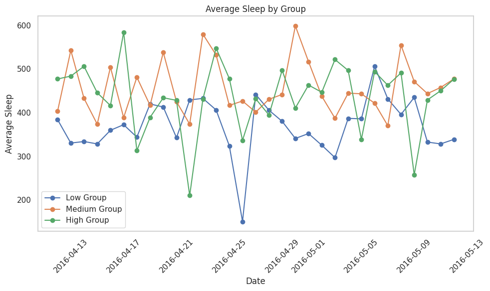

```python
# Calculate the sum of 'VeryActiveDistances' for each user
user_sum_dist = dailyActivity.groupby('Id')['VeryActiveDistance'].sum()

# Determine the thresholds for low, medium, and high distances
thresholds = user_sum_dist.quantile([1/3, 2/3])

# Function to categorize users based on distance
def categorize_distance(dist):
    if dist <= thresholds.iloc[0]:
        return 'Low'
    elif dist <= thresholds.iloc[1]:
        return 'Medium'
    else:
        return 'High'

# Apply the categorization function to each user
user_sum_dist_category = user_sum_dist.apply(categorize_distance)

# Count the occurrences of each category
category_counts = user_sum_dist_category.value_counts()

# Determine the minimum count for each category to split evenly
min_count = min(category_counts)

# Group users by category
low_group = user_sum_dist_category[user_sum_dist_category == 'Low'].index[:min_count]
medium_group = user_sum_dist_category[user_sum_dist_category == 'Medium'].index[:min_count]
high_group = user_sum_dist_category[user_sum_dist_category == 'High'].index[:min_count]

# Convert 'DateColumn' to datetime objects
dailySleep['SleepDay'] = pd.to_datetime(dailySleep['SleepDay'])

# Create DataFrames for each group
lowSleep_df = dailySleep[dailySleep['Id'].isin(low_group)]
mediumSleep_df = dailySleep[dailySleep['Id'].isin(medium_group)]
highSleep_df = dailySleep[dailySleep['Id'].isin(high_group)]

# Calculate the average Sleep for each group
low_avg = lowSleep_df.groupby('SleepDay')['TotalMinutesAsleep'].mean().tolist()
medium_avg = mediumSleep_df.groupby('SleepDay')['TotalMinutesAsleep'].mean().tolist()
high_avg = highSleep_df.groupby('SleepDay')['TotalMinutesAsleep'].mean().tolist()

# Plotting
plt.figure(figsize=(10, 6))  # Adjust the figure size as needed

# Plot the data
plt.plot(dailyActivity['ActivityDate'].unique(), low_avg, label='Low Group', marker='o')
plt.plot(dailyActivity['ActivityDate'].unique(), medium_avg, label='Medium Group', marker='o')
plt.plot(dailyActivity['ActivityDate'].unique(), high_avg, label='High Group', marker='o')

# Add labels and title
plt.xlabel('Date')
plt.ylabel('Average Sleep')
plt.title('Average Sleep by Group')
plt.xticks(rotation=45)  # Rotate x-axis labels for better readability

# Add legend
plt.legend()

# Show the plot
plt.tight_layout()  # Adjust layout
plt.grid()
plt.show()
```

The graph is tough to take conlsuons from. Seaborn will be used to form a trendline for each group and plot again.

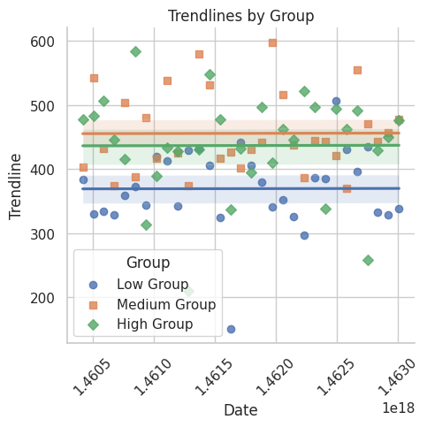

```python
# Convert timestamps to numeric values
timestamps_numeric = pd.to_numeric(dailyActivity['ActivityDate'].unique())

# Combine the lists and numeric timestamps into a DataFrame
trendline_df = pd.DataFrame({
    'Date': timestamps_numeric,
    'Low Group': low_avg,
    'Medium Group': medium_avg,
    'High Group': high_avg
})

# Melt the DataFrame to make it suitable for seaborn's lmplot
melted_df = trendline_df.melt(id_vars='Date', value_vars=['Low Group', 'Medium Group', 'High Group'], var_name='Group', value_name='Trendline')

# Create a line plot with trendlines
sns.set(style="whitegrid")
plt.figure(figsize=(10, 6))

# Use lmplot to create trendlines for each group
sns.lmplot(x='Date', y='Trendline', data=melted_df, hue='Group', markers=['o', 's', 'D'], legend_out=False)

# Add labels and title
plt.xlabel('Date')
plt.ylabel('Trendline')
plt.title('Trendlines by Group')

# Show the plot
plt.xticks(rotation=45)  # Rotate x-axis labels for better readability
plt.tight_layout()
plt.show()
```

AAAAHHHH, I'm sorry for forgetting about the project! It sounded really fun just kinda slipped my mind after the final to finish this.